# Proyecto Introduccion a la Mineria de Datos

### Librerias

Para la manipulacion y aplicar los diferentes algortimos de mineria de datos se usaron las siguientes librerias.

```r
library(ggplot2)
library(arules)
library(arules)
library(dplyr)
```

# Lectura de Datasets

Los datasets se encuentran en la carpeta datasets, estos se enceuntran en diferetnes formatos:

1. CSV, con datos normalizados
2. CSV, con datos con diccionario integrado
3. Excel, con datos normalizados
4. Excel, con datos con diccionario integrado
5. Archivo SAV, de la herramienta de IBM SPSS. Con el cual se exportaron cada una de las otras fuentes de datos.
- Los años 2022 y 2023, unicamente cuentan con fuente de datos con diccionario integrado.
- El año 2022, le hace falta el la columna hora_ocu, que identifica la hora del delito.

## Lectura de CSV

Se usaran los datos de los archivos CSV, con el diccionario integrado.Para poder integrar los datasets de los años 2022 y 2023.

```r
victimas_2016 <- read.csv("datasets/vd16.csv")
victimas_2017 <- read.csv("datasets/vd17.csv")
victimas_2018 <- read.csv("datasets/vd18.csv")
victimas_2019 <- read.csv("datasets/vd19.csv")
victimas_2020 <- read.csv("datasets/vd20.csv")
victimas_2021 <- read.csv("datasets/vd21.csv")
victimas_2022 <- read.csv("datasets/vd22.csv")
victimas_2023 <- read.csv("datasets/vd23.csv")
```

## Dataset consolidado

Se creara un dataset uniendo todos los datasets

```r
victimas <- rbind(victimas_2016, victimas_2017, victimas_2018, victimas_2019, victimas_2020, victimas_2021, victimas_2022, victimas_2023)

victimas
```

| núm_corre | año_ocu | mes_ocu | día_ocu | día_sem_ocu | hora_ocu | g_hora | g_hora_mañ.tar.noch | depto_ocu | mupio_ocu | zona_ocu | sexo_per | edad_per | g_edad_60ymás | g_edad_80ymás | edad_quinquenales | delito_com | g_delitos |
| --- | --- | --- | --- | --- | --- | --- | --- | --- | --- | --- | --- | --- | --- | --- | --- | --- | --- |
| 1 | 2016 | Enero | 1 | Viernes | 0 | 00:00 a 05:59 | 00:00 a 11:59 | Guatemala | Guatemala | 12 | Hombre | 56 | 55-59 | 55-59 | 55 - 59 | Robo de armas de fuego | Contra el patrimonio |
| 2 | 2016 | Enero | 1 | Viernes | 8 | 06:00 a 11:59 | 00:00 a 11:59 | Santa Rosa | Barberena | Ignorada | Hombre | 42 | 40-44 | 40-44 | 40 - 44 | Robo de armas de fuego | Contra el patrimonio |
| 3 | 2016 | Enero | 1 | Viernes | 8 | 06:00 a 11:59 | 00:00 a 11:59 | El Progreso | San Cristóbal Acasaguastlán | Ignorada | Hombre | 38 | 35-39 | 35-39 | 35 - 39 | Robo de armas de fuego | Contra el patrimonio |
| 4 | 2016 | Enero | 2 | Sábado | 15 | 12:00 a 17:59 | 12:00 a 17:59 | Guatemala | Palencia | Ignorada | Hombre | 69 | 60 y más | 65-69 | 65 - 69 | Robo de armas de fuego | Contra el patrimonio |
| 5 | 2016 | Enero | 2 | Sábado | 19 | 18:00 a 23:59 | 18:00 a 23:59 | Guatemala | Guatemala | 6 | Hombre | 27 | 25-29 | 25-29 | 25 - 29 | Robo de armas de fuego | Contra el patrimonio |
| 6 | 2016 | Enero | 2 | Sábado | 17 | 12:00 a 17:59 | 12:00 a 17:59 | Guatemala | Mixco | Ignorada | Hombre | 39 | 35-39 | 35-39 | 35 - 39 | Hurto de armas de fuego | Contra el patrimonio |
| 7 | 2016 | Enero | 2 | Sábado | 17 | 12:00 a 17:59 | 12:00 a 17:59 | Guatemala | Mixco | Ignorada | Hombre | 39 | 35-39 | 35-39 | 35 - 39 | Hurto de armas de fuego | Contra el patrimonio |
| 8 | 2016 | Enero | 2 | Sábado | 17 | 12:00 a 17:59 | 12:00 a 17:59 | Guatemala | Mixco | Ignorada | Hombre | 39 | 35-39 | 35-39 | 35 - 39 | Hurto de armas de fuego | Contra el patrimonio |
| 9 | 2016 | Enero | 2 | Sábado | 9 | 06:00 a 11:59 | 00:00 a 11:59 | Escuintla | Palín | Ignorada | Hombre | 25 | 25-29 | 25-29 | 25 - 29 | Hurto de armas de fuego | Contra el patrimonio |
| 10 | 2016 | Enero | 2 | Sábado | 13 | 12:00 a 17:59 | 12:00 a 17:59 | Escuintla | Tiquisate | Ignorada | Hombre | 36 | 35-39 | 35-39 | 35 - 39 | Robo de armas de fuego | Contra el patrimonio |

[output cut: 990 more lines]

```r
NA
```

El dataset final, Tiene el tamaño de 248076 x 18 variables.

# Reglas de Asociacion

Para las reglas de asociacion tenemos dos opcions Apriori o FP-Growth. Las asociaciones seran aplicadas con FP-Growth, Y se basaran todas filtrando en base al grupo del delitoy el genero de al victima:

## Primera asociacion

Podemos partir en la separacion de delitos para un estudio mas filtrado entre los diferentes tipos de delitos que sufren los guatemaltecos.

### Victimas de homicidios

```r
victimas_aso <- victimas %>%
  filter(g_delitos == "Homicidios") %>%
  select(-núm_corre,-g_delitos, -zona_ocu, -g_hora, -día_ocu)

r <- fim4r(victimas_aso, method="fpgrowth", target="rules", supp=.25, conf=.5)
```

```
fim4r.fpgrowth

Parameter specification:
```

|  | supp | conf | target | report |
| --- | --- | --- | --- | --- |
|  | 25 | 50 | rules | scl |

```
Data size: 26179 transactions and 562 items
Result: 21 rules
```

```r
rframe <- as(r, "data.frame")
rframe
```

|  | rules | support | confidence | lift | count |
| --- | --- | --- | --- | --- | --- |
| 1 | {} => {sexo_per=Hombre} | 0.8596203 | 0.8596203 | 1.0000000 | 22504 |
| 2 | {delito_com=Homicidio por arma de fuego} => {sexo_per=Hombre} | 0.6983842 | 0.8748265 | 1.0176895 | 18283 |
| 3 | {sexo_per=Hombre} => {delito_com=Homicidio por arma de fuego} | 0.6983842 | 0.8124333 | 1.0176895 | 18283 |
| 4 | {} => {delito_com=Homicidio por arma de fuego} | 0.7983116 | 0.7983116 | 1.0000000 | 20899 |
| 5 | {año_ocu=[2017,2020)} => {sexo_per=Hombre} | 0.3879445 | 0.8554582 | 0.9951582 | 10156 |
| 6 | {año_ocu=[2017,2020),delito_com=Homicidio por arma de fuego} => {sexo_per=Hombre} | 0.3128462 | 0.8739729 | 1.0166964 | 8189 |
| 7 | {año_ocu=[2017,2020),sexo_per=Hombre} => {delito_com=Homicidio por arma de fuego} | 0.3128462 | 0.8064199 | 1.0101567 | 8189 |
| 8 | {año_ocu=[2017,2020)} => {delito_com=Homicidio por arma de fuego} | 0.3579587 | 0.7893363 | 0.9887571 | 9371 |
| 9 | {depto_ocu=Guatemala} => {sexo_per=Hombre} | 0.3292334 | 0.8376907 | 0.9744892 | 8619 |
| 10 | {depto_ocu=Guatemala,delito_com=Homicidio por arma de fuego} => {sexo_per=Hombre} | 0.2789641 | 0.8549520 | 0.9945693 | 7302 |

[output cut: 11 more lines]

De estos resultados podemos deducir varias cosas. Como que el homicidio por arma de fuego es el delito cometido a las victimas de homicidido en conjunto con que este delito se incremento del 2020 al 2023 en el departamento de Guatemala.

Pero vemos que la tendencia por la cantidad de homicidios que sufren los hombres en Guatemala es mayor que las Mujeres. Por lo que vamos a separar el sexo de las personas para ver las tendencias de Homicidios en Hombre y Mujeres respectivamente.

#### Hombres victimas de homicidios

```r
victimas_aso <- victimas %>%
  filter(g_delitos == "Homicidios" & sexo_per == "Hombre") %>%
  select(-núm_corre,-g_delitos, -zona_ocu, -g_hora, -día_ocu, -sexo_per)

r <- fim4r(victimas_aso, method="fpgrowth", target="rules", supp=.25, conf=.5)
```

```
fim4r.fpgrowth

Parameter specification:
```

|  | supp | conf | target | report |
| --- | --- | --- | --- | --- |
|  | 25 | 50 | rules | scl |

```
Data size: 22504 transactions and 552 items
Result: 5 rules
```

```r
rframe <- as(r, "data.frame")
rframe
```

|  | rules | support | confidence | lift | count |
| --- | --- | --- | --- | --- | --- |
| 1 | {} => {delito_com=Homicidio por arma de fuego} | 0.8124333 | 0.8124333 | 1.0000000 | 18283 |
| 2 | {año_ocu=[2017,2020)} => {delito_com=Homicidio por arma de fuego} | 0.3639353 | 0.8064199 | 0.9925982 | 8190 |
| 3 | {g_hora_mañ.tar.noch=18:00 a 23:59} => {delito_com=Homicidio por arma de fuego} | 0.3441166 | 0.8743367 | 1.0761950 | 7744 |
| 4 | {depto_ocu=Guatemala} => {delito_com=Homicidio por arma de fuego} | 0.3245201 | 0.8473141 | 1.0429336 | 7303 |
| 5 | {año_ocu=[2020,2023]} => {delito_com=Homicidio por arma de fuego} | 0.3079453 | 0.8250000 | 1.0154679 | 6930 |

#### Muejeres victimas de homicidios

```r
victimas_aso <- victimas %>%
  filter(g_delitos == "Homicidios" & sexo_per == "Mujer") %>%
  select(-núm_corre,-g_delitos, -zona_ocu, -g_hora, -día_ocu, -sexo_per)

r <- fim4r(victimas_aso, method="fpgrowth", target="rules", supp=.25, conf=.5)
```

```
fim4r.fpgrowth

Parameter specification:
```

|  | supp | conf | target | report |
| --- | --- | --- | --- | --- |
|  | 25 | 50 | rules | scl |

```
Data size: 3675 transactions and 494 items
Result: 4 rules
```

```r
rframe <- as(r, "data.frame")
rframe
```

|  | rules | support | confidence | lift | count |
| --- | --- | --- | --- | --- | --- |
| 1 | {} => {delito_com=Homicidio por arma de fuego} | 0.7118367 | 0.7118367 | 1.000000 | 2616 |
| 2 | {depto_ocu=Guatemala} => {delito_com=Homicidio por arma de fuego} | 0.3371429 | 0.7419162 | 1.042256 | 1239 |
| 3 | {g_hora_mañ.tar.noch=18:00 a 23:59} => {delito_com=Homicidio por arma de fuego} | 0.3044898 | 0.8132267 | 1.142434 | 1119 |
| 4 | {año_ocu=[2020,2023]} => {delito_com=Homicidio por arma de fuego} | 0.2783673 | 0.7380952 | 1.036888 | 1023 |

Nos da informacion similar al analisis de los hombres victimas de homicidio. Y podemos asociar lo siguiente:

- Que los homicidios de las mujeres por arma de fuego se dieron principalmente del 2020 al 2023.
- Que los homicidios de las mujeres por arma de fuego se dieron por la noche.
- Que los homicidios de las mujeres por arma de fuego se dieron en el departamento de Guatemala.

## Segunda Asociacion

Seguiremos con el analisis separandolo por el grupo de delitos, ahora para otro tipo de de delito.

### Victimas de Lesiones

```r
victimas_aso <- victimas %>%
  filter(g_delitos == "Lesiones") %>%
  select(-núm_corre,-g_delitos, -zona_ocu, -g_hora, -día_ocu)

r <- fim4r(victimas_aso, method="fpgrowth", target="rules", supp=.25, conf=.5)
```

```
fim4r.fpgrowth

Parameter specification:
```

|  | supp | conf | target | report |
| --- | --- | --- | --- | --- |
|  | 25 | 50 | rules | scl |

```
Data size: 27931 transactions and 560 items
Result: 20 rules
```

```r
rframe <- as(r, "data.frame")
rframe
```

|  | rules | support | confidence | lift | count |
| --- | --- | --- | --- | --- | --- |
| 1 | {} => {sexo_per=Hombre} | 0.8439726 | 0.8439726 | 1.0000000 | 23573 |
| 2 | {delito_com=Lesiones por arma de fuego} => {sexo_per=Hombre} | 0.5079661 | 0.8476014 | 1.0042996 | 14188 |
| 3 | {sexo_per=Hombre} => {delito_com=Lesiones por arma de fuego} | 0.5079661 | 0.6018750 | 1.0042996 | 14188 |
| 4 | {} => {delito_com=Lesiones por arma de fuego} | 0.5992983 | 0.5992983 | 1.0000000 | 16739 |
| 5 | {depto_ocu=Guatemala} => {sexo_per=Hombre} | 0.4436289 | 0.8498045 | 1.0069101 | 12391 |
| 6 | {sexo_per=Hombre} => {depto_ocu=Guatemala} | 0.4436289 | 0.5256437 | 1.0069101 | 12391 |
| 7 | {depto_ocu=Guatemala,delito_com=Lesiones por arma de fuego} => {sexo_per=Hombre} | 0.2721349 | 0.8455891 | 1.0019152 | 7601 |
| 8 | {depto_ocu=Guatemala,sexo_per=Hombre} => {delito_com=Lesiones por arma de fuego} | 0.2721349 | 0.6134291 | 1.0235790 | 7601 |
| 9 | {sexo_per=Hombre,delito_com=Lesiones por arma de fuego} => {depto_ocu=Guatemala} | 0.2721349 | 0.5357344 | 1.0262395 | 7601 |
| 10 | {depto_ocu=Guatemala} => {delito_com=Lesiones por arma de fuego} | 0.3218288 | 0.6164872 | 1.0286818 | 8989 |

[output cut: 10 more lines]

Por estes analisis podemos determinar que el mayor delito por Lesion, Lesion por arma de fuego. Y que son los hombres en el departamento de Guatemala los que son mas victimas de este delito.

Para ver si las mujeres mantinen esta tendencia haremos el filtrado para cada sexo.

#### Hombres victimas de lesiones

```r
victimas_aso <- victimas %>%
  filter(g_delitos == "Lesiones" & sexo_per == "Hombre") %>%
  select(-núm_corre,-g_delitos, -zona_ocu, -g_hora, -día_ocu, -sexo_per)

r <- fim4r(victimas_aso, method="fpgrowth", target="rules", supp=.25, conf=.5)
```

```
fim4r.fpgrowth

Parameter specification:
```

|  | supp | conf | target | report |
| --- | --- | --- | --- | --- |
|  | 25 | 50 | rules | scl |

```
Data size: 23573 transactions and 555 items
Result: 9 rules
```

```r
rframe <- as(r, "data.frame")
rframe
```

|  | rules | support | confidence | lift | count |
| --- | --- | --- | --- | --- | --- |
| 1 | {} => {delito_com=Lesiones por arma de fuego} | 0.6018750 | 0.6018750 | 1.000000 | 14188 |
| 2 | {depto_ocu=Guatemala} => {delito_com=Lesiones por arma de fuego} | 0.3224452 | 0.6134291 | 1.019197 | 7601 |
| 3 | {delito_com=Lesiones por arma de fuego} => {depto_ocu=Guatemala} | 0.3224452 | 0.5357344 | 1.019197 | 7601 |
| 4 | {} => {depto_ocu=Guatemala} | 0.5256437 | 0.5256437 | 1.000000 | 12391 |
| 5 | {g_hora_mañ.tar.noch=18:00 a 23:59} => {delito_com=Lesiones por arma de fuego} | 0.2891444 | 0.6193548 | 1.029042 | 6816 |
| 8 | {g_hora_mañ.tar.noch=18:00 a 23:59} => {depto_ocu=Guatemala} | 0.2514741 | 0.5386642 | 1.024771 | 5927 |
| 9 | {año_ocu=[2019,2023]} => {delito_com=Lesiones por arma de fuego} | 0.2692063 | 0.6028881 | 1.001683 | 6346 |
| 19 | {mupio_ocu=Guatemala} => {depto_ocu=Guatemala} | 0.2692911 | 1.0000000 | 1.902429 | 6348 |
| 20 | {depto_ocu=Guatemala} => {mupio_ocu=Guatemala} | 0.2692911 | 0.5123073 | 1.902429 | 6348 |

Nos da informacion similar a ver el analisis sin filtrar el sexo de la victima. Y podemos asociar lo siguiente:

- Que las lesiones de los hombres por arma de fuego se dieron por la noche.
- Que las lesiones de los hombres por arma de fuego se dieron en el departamento de Guatemala.

#### Mujeres victimas de lesiones

```r
victimas_aso <- victimas %>%
  filter(g_delitos == "Lesiones" & sexo_per == "Mujer") %>%
  select(-núm_corre,-g_delitos, -zona_ocu, -g_hora, -día_ocu, -sexo_per)

r <- fim4r(victimas_aso, method="fpgrowth", target="rules", supp=.25, conf=.5)
```

```
fim4r.fpgrowth

Parameter specification:
```

|  | supp | conf | target | report |
| --- | --- | --- | --- | --- |
|  | 25 | 50 | rules | scl |

```
Data size: 4358 transactions and 487 items
Result: 8 rules
```

```r
rframe <- as(r, "data.frame")
rframe
```

|  | rules | support | confidence | lift | count |
| --- | --- | --- | --- | --- | --- |
| 1 | {} => {delito_com=Lesiones por arma de fuego} | 0.5853603 | 0.5853603 | 1.000000 | 2551 |
| 2 | {depto_ocu=Guatemala} => {delito_com=Lesiones por arma de fuego} | 0.3184947 | 0.6337900 | 1.082735 | 1388 |
| 3 | {delito_com=Lesiones por arma de fuego} => {depto_ocu=Guatemala} | 0.3184947 | 0.5441004 | 1.082735 | 1388 |
| 4 | {} => {depto_ocu=Guatemala} | 0.5025241 | 0.5025241 | 1.000000 | 2190 |
| 5 | {g_hora_mañ.tar.noch=18:00 a 23:59} => {delito_com=Lesiones por arma de fuego} | 0.2861404 | 0.6176325 | 1.055132 | 1247 |
| 8 | {año_ocu=[2017,2020)} => {delito_com=Lesiones por arma de fuego} | 0.2760441 | 0.6226708 | 1.063739 | 1203 |
| 17 | {mupio_ocu=Guatemala} => {depto_ocu=Guatemala} | 0.2650298 | 1.0000000 | 1.989954 | 1155 |
| 18 | {depto_ocu=Guatemala} => {mupio_ocu=Guatemala} | 0.2650298 | 0.5273973 | 1.989954 | 1155 |

Nos da informacion similar a ver el analisis de los hombre. Y podemos asociar lo siguiente:

- Que las lesiones de las mujeres por arma de fuego se dieron por la noche.
- Que las lesiones de los mujeres por arma de fuego se dieron en el departamento de Guatemala.

## Tercera Asociacion

### Victimas contra el patrimonio

```r
victimas_aso <- victimas %>%
  filter(g_delitos == "Contra el patrimonio") %>%
  select(-núm_corre,-g_delitos, -zona_ocu, -g_hora, -día_ocu)

r <- fim4r(victimas_aso, method="fpgrowth", target="rules", supp=.2, conf=.5)
```

```
fim4r.fpgrowth

Parameter specification:
```

|  | supp | conf | target | report |
| --- | --- | --- | --- | --- |
|  | 20 | 50 | rules | scl |

```
Data size: 76825 transactions and 593 items
Result: 18 rules
```

```r
rframe <- as(r, "data.frame")
rframe
```

|  | rules | support | confidence | lift | count |
| --- | --- | --- | --- | --- | --- |
| 1 | {} => {sexo_per=Hombre} | 0.8177286 | 0.8177286 | 1.0000000 | 62822 |
| 2 | {depto_ocu=Guatemala} => {sexo_per=Hombre} | 0.4230264 | 0.8331368 | 1.0188427 | 32499 |
| 3 | {sexo_per=Hombre} => {depto_ocu=Guatemala} | 0.4230264 | 0.5173188 | 1.0188427 | 32499 |
| 4 | {} => {depto_ocu=Guatemala} | 0.5077514 | 0.5077514 | 1.0000000 | 39008 |
| 5 | {año_ocu=[2017,2020)} => {sexo_per=Hombre} | 0.3358021 | 0.8158502 | 0.9977029 | 25798 |
| 7 | {año_ocu=[2020,2023]} => {sexo_per=Hombre} | 0.3298405 | 0.8217401 | 1.0049057 | 25340 |
| 10 | {año_ocu=[2020,2023]} => {depto_ocu=Guatemala} | 0.2242369 | 0.5586471 | 1.1002374 | 17227 |
| 11 | {g_hora_mañ.tar.noch=00:00 a 11:59} => {sexo_per=Hombre} | 0.3243736 | 0.8294777 | 1.0143680 | 24919 |
| 14 | {g_hora_mañ.tar.noch=00:00 a 11:59} => {depto_ocu=Guatemala} | 0.2076928 | 0.5311054 | 1.0459950 | 15956 |
| 15 | {g_hora_mañ.tar.noch=18:00 a 23:59} => {sexo_per=Hombre} | 0.2703547 | 0.8332330 | 1.0189604 | 20770 |

[output cut: 8 more lines]

Por estes analisis podemos observar que no mayor asociacion evidente, Se procedera a el filtrado por sexo para determinar si entre hombre y mujeres hay una asociacion mas directa.

#### Victimas hombres en contra el patrimonio

```r
victimas_aso <- victimas %>%
  filter(g_delitos == "Contra el patrimonio" & sexo_per == "Hombre") %>%
  select(-núm_corre,-g_delitos, -zona_ocu, -g_hora, -día_ocu, -sexo_per)

r <- fim4r(victimas_aso, method="fpgrowth", target="rules", supp=.2, conf=.5)
```

```
fim4r.fpgrowth

Parameter specification:
```

|  | supp | conf | target | report |
| --- | --- | --- | --- | --- |
|  | 20 | 50 | rules | scl |

```
Data size: 62822 transactions and 582 items
Result: 5 rules
```

```r
rframe <- as(r, "data.frame")
rframe
```

|  | rules | support | confidence | lift | count |
| --- | --- | --- | --- | --- | --- |
| 1 | {} => {depto_ocu=Guatemala} | 0.5173188 | 0.5173188 | 1.000000 | 32499 |
| 2 | {año_ocu=[2020,2023]} => {depto_ocu=Guatemala} | 0.2317978 | 0.5746646 | 1.110852 | 14562 |
| 3 | {g_hora_mañ.tar.noch=00:00 a 11:59} => {depto_ocu=Guatemala} | 0.2151316 | 0.5423355 | 1.048358 | 13515 |
| 5 | {mupio_ocu=Guatemala} => {depto_ocu=Guatemala} | 0.3092547 | 1.0000000 | 1.933044 | 19428 |
| 6 | {depto_ocu=Guatemala} => {mupio_ocu=Guatemala} | 0.3092547 | 0.5978030 | 1.933044 | 19428 |

No nos da un delito particular pero si podemos asociar lo siguiente:

- Que los delitos en contra el patrimonio en los hombres se dieron por la mañana en el departamento de Guatemala.

#### Victimas mujeres en contra el patrimonio

```r
victimas_aso <- victimas %>%
  filter(g_delitos == "Contra el patrimonio" & sexo_per == "Mujer") %>%
  select(-núm_corre,-g_delitos, -zona_ocu, -g_hora, -día_ocu, -sexo_per)

r <- fim4r(victimas_aso, method="fpgrowth", target="rules", supp=.2, conf=.5)
```

```
fim4r.fpgrowth

Parameter specification:
```

|  | supp | conf | target | report |
| --- | --- | --- | --- | --- |
|  | 20 | 50 | rules | scl |

```
Data size: 13996 transactions and 544 items
Result: 2 rules
```

```r
rframe <- as(r, "data.frame")
rframe
```

|  | rules | support | confidence | lift | count |
| --- | --- | --- | --- | --- | --- |
| 1 | {mupio_ocu=Guatemala} => {depto_ocu=Guatemala} | 0.2718634 | 1.0000000 | 2.150914 | 3805 |
| 2 | {depto_ocu=Guatemala} => {mupio_ocu=Guatemala} | 0.2718634 | 0.5847549 | 2.150914 | 3805 |

## Cuarta Asociacion

### Victimas contra la libertad

```r
victimas_aso <- victimas %>%
  filter(g_delitos == "Contra la libertad") %>%
  select(-núm_corre,-g_delitos, -zona_ocu, -g_hora, -día_ocu, -g_edad_60ymás, -g_edad_80ymás)

r <- fim4r(victimas_aso, method="fpgrowth", target="rules", supp=.2, conf=.5)
```

```
fim4r.fpgrowth

Parameter specification:
```

|  | supp | conf | target | report |
| --- | --- | --- | --- | --- |
|  | 20 | 50 | rules | scl |

```
Data size: 19786 transactions and 537 items
Result: 29 rules
```

```r
rframe <- as(r, "data.frame")
rframe
```

|  | rules | support | confidence | lift | count |
| --- | --- | --- | --- | --- | --- |
| 1 | {} => {delito_com=Desaparecidos} | 0.9924694 | 0.9924694 | 1.0000000 | 19637 |
| 2 | {sexo_per=Mujer} => {delito_com=Desaparecidos} | 0.5994137 | 0.9965549 | 1.0041165 | 11860 |
| 3 | {delito_com=Desaparecidos} => {sexo_per=Mujer} | 0.5994137 | 0.6039619 | 1.0041165 | 11860 |
| 4 | {} => {sexo_per=Mujer} | 0.6014859 | 0.6014859 | 1.0000000 | 11901 |
| 5 | {año_ocu=[2020,2023]} => {delito_com=Desaparecidos} | 0.4171637 | 0.9957775 | 1.0033332 | 8254 |
| 6 | {año_ocu=[2020,2023],sexo_per=Mujer} => {delito_com=Desaparecidos} | 0.2558375 | 0.9988161 | 1.0063948 | 5062 |
| 7 | {año_ocu=[2020,2023],delito_com=Desaparecidos} => {sexo_per=Mujer} | 0.2558375 | 0.6132784 | 1.0196056 | 5062 |
| 8 | {año_ocu=[2020,2023]} => {sexo_per=Mujer} | 0.2561407 | 0.6114127 | 1.0165038 | 5068 |
| 9 | {sexo_per=Hombre} => {delito_com=Desaparecidos} | 0.3930557 | 0.9876810 | 0.9951752 | 7777 |
| 10 | {g_hora_mañ.tar.noch=00:00 a 11:59} => {delito_com=Desaparecidos} | 0.3813808 | 0.9994702 | 1.0070539 | 7545 |

[output cut: 19 more lines]

Por estes analisis podemos determinar que el mayor delito encontra de la libertad, es la desaparicion. Y que son las mujeresen las que son mas victimas de este delito.

Para ver si los hombres mantinen esta tendencia haremos el filtrado para cada sexo.

#### Victimas hombres contra su libertad

```r
victimas_aso <- victimas %>%
  filter(g_delitos == "Contra la libertad" & sexo_per == "Hombre") %>%
  select(-núm_corre,-g_delitos, -zona_ocu, -g_hora, -día_ocu, -sexo_per, -g_edad_60ymás, -g_edad_80ymás)

r <- fim4r(victimas_aso, method="fpgrowth", target="rules", supp=.2, conf=.5)
```

```
fim4r.fpgrowth

Parameter specification:
```

|  | supp | conf | target | report |
| --- | --- | --- | --- | --- |
|  | 20 | 50 | rules | scl |

```
Data size: 7874 transactions and 509 items
Result: 8 rules
```

```r
rframe <- as(r, "data.frame")
rframe
```

|  | rules | support | confidence | lift | count |
| --- | --- | --- | --- | --- | --- |
| 1 | {} => {delito_com=Desaparecidos} | 0.9876810 | 0.9876810 | 1.0000000 | 7777 |
| 2 | {año_ocu=[2017,2020)} => {delito_com=Desaparecidos} | 0.3982728 | 0.9843063 | 0.9965833 | 3136 |
| 3 | {año_ocu=[2020,2023]} => {delito_com=Desaparecidos} | 0.4053848 | 0.9943925 | 1.0067953 | 3192 |
| 4 | {g_hora_mañ.tar.noch=00:00 a 11:59} => {delito_com=Desaparecidos} | 0.3989078 | 0.9990458 | 1.0115066 | 3141 |
| 5 | {depto_ocu=Guatemala} => {delito_com=Desaparecidos} | 0.3755398 | 0.9942838 | 1.0066852 | 2957 |
| 6 | {g_hora_mañ.tar.noch=12:00 a 17:59} => {delito_com=Desaparecidos} | 0.3528067 | 1.0000000 | 1.0124727 | 2778 |
| 7 | {edad_quinquenales=15 - 19} => {delito_com=Desaparecidos} | 0.2340615 | 0.9924610 | 1.0048396 | 1843 |
| 8 | {g_hora_mañ.tar.noch=18:00 a 23:59} => {delito_com=Desaparecidos} | 0.2322835 | 0.9994536 | 1.0119194 | 1829 |

#### Victimas mujeres contra su linertad

```r
victimas_aso <- victimas %>%
  filter(g_delitos == "Contra la libertad" & sexo_per == "Mujer") %>%
  select(-núm_corre,-g_delitos, -zona_ocu, -g_hora, -día_ocu, -sexo_per, -g_edad_60ymás, -g_edad_80ymás)

r <- fim4r(victimas_aso, method="fpgrowth", target="rules", supp=.2, conf=.5)
```

```
fim4r.fpgrowth

Parameter specification:
```

|  | supp | conf | target | report |
| --- | --- | --- | --- | --- |
|  | 20 | 50 | rules | scl |

```
Data size: 11901 transactions and 518 items
Result: 10 rules
```

```r
rframe <- as(r, "data.frame")
rframe
```

|  | rules | support | confidence | lift | count |
| --- | --- | --- | --- | --- | --- |
| 1 | {} => {delito_com=Desaparecidos} | 0.9965549 | 0.9965549 | 1.0000000 | 11860 |
| 2 | {edad_quinquenales=15 - 19} => {delito_com=Desaparecidos} | 0.4613898 | 0.9985452 | 1.0019972 | 5491 |
| 3 | {año_ocu=[2020,2023]} => {delito_com=Desaparecidos} | 0.4253424 | 0.9988161 | 1.0022690 | 5062 |
| 4 | {depto_ocu=Guatemala} => {delito_com=Desaparecidos} | 0.3711453 | 0.9986435 | 1.0020958 | 4417 |
| 5 | {g_hora_mañ.tar.noch=00:00 a 11:59} => {delito_com=Desaparecidos} | 0.3701370 | 0.9997730 | 1.0032293 | 4405 |
| 6 | {g_hora_mañ.tar.noch=12:00 a 17:59} => {delito_com=Desaparecidos} | 0.3559365 | 1.0000000 | 1.0034570 | 4236 |
| 7 | {año_ocu=[2016,2018)} => {delito_com=Desaparecidos} | 0.3270313 | 0.9951419 | 0.9985821 | 3891 |
| 10 | {g_hora_mañ.tar.noch=18:00 a 23:59} => {delito_com=Desaparecidos} | 0.2658600 | 1.0000000 | 1.0034570 | 3164 |
| 11 | {edad_quinquenales=10 - 14} => {delito_com=Desaparecidos} | 0.2494748 | 0.9983188 | 1.0017699 | 2969 |
| 12 | {año_ocu=[2018,2020)} => {delito_com=Desaparecidos} | 0.2441812 | 0.9945243 | 0.9979624 | 2906 |

## Quinta Asociacion

### Victimas de extorsion

```r
victimas_aso <- victimas %>%
  filter(g_delitos == "Extorsión") %>%
  select(-núm_corre,-g_delitos, -zona_ocu, -g_hora, -día_ocu, -g_edad_60ymás, -g_edad_80ymás)

r <- fim4r(victimas_aso, method="fpgrowth", target="rules", supp=.2, conf=.5)
```

```
fim4r.fpgrowth

Parameter specification:
```

|  | supp | conf | target | report |
| --- | --- | --- | --- | --- |
|  | 20 | 50 | rules | scl |

```
Data size: 79486 transactions and 533 items
Result: 14 rules
```

```r
rframe <- as(r, "data.frame")
rframe
```

|  | rules | support | confidence | lift | count |
| --- | --- | --- | --- | --- | --- |
| 1 | {} => {sexo_per=Hombre} | 0.6298216 | 0.6298216 | 1.0000000 | 50062 |
| 2 | {delito_com=Extorsión a residencias} => {sexo_per=Hombre} | 0.3412676 | 0.5955083 | 0.9455191 | 27126 |
| 3 | {sexo_per=Hombre} => {delito_com=Extorsión a residencias} | 0.3412676 | 0.5418481 | 0.9455191 | 27126 |
| 4 | {} => {delito_com=Extorsión a residencias} | 0.5730695 | 0.5730695 | 1.0000000 | 45551 |
| 5 | {g_hora_mañ.tar.noch=12:00 a 17:59} => {sexo_per=Hombre} | 0.3071610 | 0.6310416 | 1.0019371 | 24415 |
| 8 | {g_hora_mañ.tar.noch=12:00 a 17:59} => {delito_com=Extorsión a residencias} | 0.2816722 | 0.5786767 | 1.0097845 | 22389 |
| 9 | {depto_ocu=Guatemala} => {sexo_per=Hombre} | 0.2849433 | 0.6242834 | 0.9912066 | 22649 |
| 13 | {año_ocu=[2019,2021)} => {sexo_per=Hombre} | 0.2255366 | 0.6461344 | 1.0259007 | 17927 |
| 16 | {año_ocu=[2019,2021)} => {delito_com=Extorsión a residencias} | 0.2034572 | 0.5828798 | 1.0171189 | 16171 |
| 18 | {sexo_per=Mujer} => {delito_com=Extorsión a residencias} | 0.2214730 | 0.6362355 | 1.1102240 | 17604 |

[output cut: 4 more lines]

Por estes analisis podemos determinar que el mayor delito de extrosion, es la extorsion a residencias. Y que son los hombres mnas victimas de este delito

Para ver si las mujeres mantinen esta tendencia haremos el filtrado para cada sexo.

#### Victimas hombres de extorsion

```r
victimas_aso <- victimas %>%
  filter(g_delitos == "Extorsión" & sexo_per == "Hombre") %>%
  select(-núm_corre,-g_delitos, -zona_ocu, -g_hora, -día_ocu, -sexo_per, -g_edad_60ymás, -g_edad_80ymás)

r <- fim4r(victimas_aso, method="fpgrowth", target="rules", supp=.2, conf=.5)
```

```
fim4r.fpgrowth

Parameter specification:
```

|  | supp | conf | target | report |
| --- | --- | --- | --- | --- |
|  | 20 | 50 | rules | scl |

```
Data size: 50062 transactions and 527 items
Result: 4 rules
```

```r
rframe <- as(r, "data.frame")
rframe
```

|  | rules | support | confidence | lift | count |
| --- | --- | --- | --- | --- | --- |
| 1 | {} => {delito_com=Extorsión a residencias} | 0.5418481 | 0.5418481 | 1.000000 | 27126 |
| 2 | {g_hora_mañ.tar.noch=12:00 a 17:59} => {delito_com=Extorsión a residencias} | 0.2687867 | 0.5511366 | 1.017142 | 13456 |
| 4 | {delito_com=Extorsión a comercios} => {depto_ocu=Guatemala} | 0.2035876 | 0.5753316 | 1.271679 | 10192 |
| 11 | {mupio_ocu=Guatemala} => {depto_ocu=Guatemala} | 0.2225440 | 1.0000000 | 2.210340 | 11141 |

#### Victimas mujeres de extorsion

```r
victimas_aso <- victimas %>%
  filter(g_delitos == "Extorsión" & sexo_per == "Mujer") %>%
  select(-núm_corre,-g_delitos, -zona_ocu, -g_hora, -día_ocu, -sexo_per, -g_edad_60ymás, -g_edad_80ymás)

r <- fim4r(victimas_aso, method="fpgrowth", target="rules", supp=.2, conf=.5)
```

```
fim4r.fpgrowth

Parameter specification:
```

|  | supp | conf | target | report |
| --- | --- | --- | --- | --- |
|  | 20 | 50 | rules | scl |

```
Data size: 27669 transactions and 508 items
Result: 7 rules
```

```r
rframe <- as(r, "data.frame")
rframe
```

|  | rules | support | confidence | lift | count |
| --- | --- | --- | --- | --- | --- |
| 1 | {} => {delito_com=Extorsión a residencias} | 0.6362355 | 0.6362355 | 1.0000000 | 17604 |
| 2 | {g_hora_mañ.tar.noch=12:00 a 17:59} => {delito_com=Extorsión a residencias} | 0.3106365 | 0.6357719 | 0.9992713 | 8595 |
| 3 | {depto_ocu=Guatemala} => {delito_com=Extorsión a residencias} | 0.2514366 | 0.5717926 | 0.8987121 | 6956 |
| 4 | {año_ocu=[2021,2022]} => {delito_com=Extorsión a residencias} | 0.2458347 | 0.6281862 | 0.9873485 | 6802 |
| 7 | {año_ocu=[2021,2022]} => {g_hora_mañ.tar.noch=12:00 a 17:59} | 0.2016697 | 0.5153306 | 1.0547143 | 5580 |
| 8 | {año_ocu=[2019,2021)} => {delito_com=Extorsión a residencias} | 0.2131627 | 0.6330364 | 0.9949718 | 5898 |
| 16 | {mupio_ocu=Guatemala} => {depto_ocu=Guatemala} | 0.2016336 | 1.0000000 | 2.2741021 | 5579 |

# Análisis de clúster

```r
victimas_2016 <- read.csv("datasets/v16.csv")
victimas_2017 <- read.csv("datasets/v17.csv")
victimas_2018 <- read.csv("datasets/v18.csv")
victimas_2019 <- read.csv("datasets/v19.csv")
victimas_2020 <- read.csv("datasets/v20.csv")
victimas_2021 <- read.csv("datasets/v21.csv")

victimas <- rbind(victimas_2016, victimas_2017, victimas_2018, victimas_2019, victimas_2020, victimas_2021)

victimas
```

| núm_corre | año_ocu | mes_ocu | día_ocu | día_sem_ocu | hora_ocu | g_hora | g_hora_mañ.tar.noch | depto_ocu | mupio_ocu | zona_ocu | sexo_per | edad_per | g_edad_60ymás | g_edad_80ymás | edad_quinquenales | delito_com | g_delitos |
| --- | --- | --- | --- | --- | --- | --- | --- | --- | --- | --- | --- | --- | --- | --- | --- | --- | --- |
| 1 | 2016 | 1 | 1 | 5 | 0 | 1 | 1 | 1 | 101 | 12 | 1 | 56 | 10 | 10 | 12 | 69 | 3 |
| 2 | 2016 | 1 | 1 | 5 | 8 | 2 | 1 | 6 | 602 | 99 | 1 | 42 | 7 | 7 | 9 | 69 | 3 |
| 3 | 2016 | 1 | 1 | 5 | 8 | 2 | 1 | 2 | 204 | 99 | 1 | 38 | 6 | 6 | 8 | 69 | 3 |
| 4 | 2016 | 1 | 2 | 6 | 15 | 3 | 2 | 1 | 105 | 99 | 1 | 69 | 11 | 12 | 14 | 69 | 3 |
| 5 | 2016 | 1 | 2 | 6 | 19 | 4 | 3 | 1 | 101 | 6 | 1 | 27 | 4 | 4 | 6 | 69 | 3 |
| 6 | 2016 | 1 | 2 | 6 | 17 | 3 | 2 | 1 | 108 | 99 | 1 | 39 | 6 | 6 | 8 | 75 | 3 |
| 7 | 2016 | 1 | 2 | 6 | 17 | 3 | 2 | 1 | 108 | 99 | 1 | 39 | 6 | 6 | 8 | 75 | 3 |
| 8 | 2016 | 1 | 2 | 6 | 17 | 3 | 2 | 1 | 108 | 99 | 1 | 39 | 6 | 6 | 8 | 75 | 3 |
| 9 | 2016 | 1 | 2 | 6 | 9 | 2 | 1 | 5 | 511 | 99 | 1 | 25 | 4 | 4 | 6 | 75 | 3 |
| 10 | 2016 | 1 | 2 | 6 | 13 | 3 | 2 | 5 | 506 | 99 | 1 | 36 | 6 | 6 | 8 | 69 | 3 |

[output cut: 990 more lines]

### Cluster - Delito vs Edad de victima

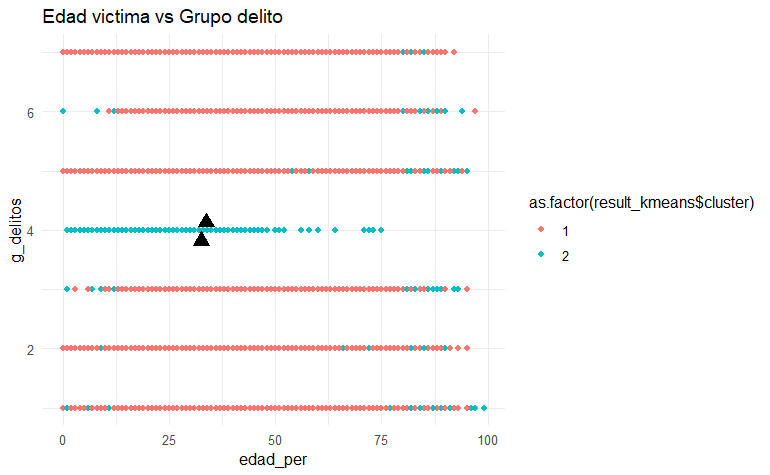

```r
victimas_cluster <- victimas %>%
  filter(edad_per < 100)


result_kmeans  <- kmeans (victimas_cluster, centers = 2)

ggplot(victimas_cluster, aes(x = edad_per , y = g_delitos , color = as.factor(result_kmeans$cluster))) +
  geom_point() +
  geom_point(data = as.data.frame(result_kmeans$centers), aes(x = edad_per, y = g_delitos), color = "black", size = 4, shape = 17) +
  labs(title = "Edad victima vs Grupo delito") +
  theme_minimal()
```

### Cluster - Homicidios

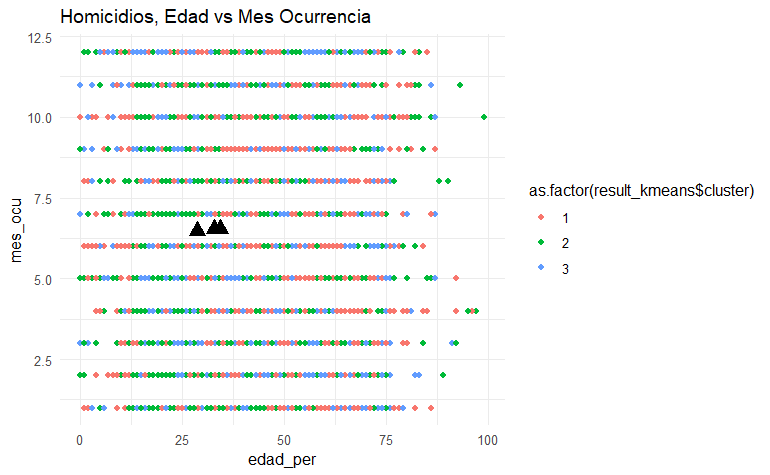

```r
victimas_cluster <- victimas%>%
  filter(edad_per <100)%>%
  filter(g_delitos == 1)%>% #Homicidios
  select(-núm_corre, -zona_ocu, -g_hora, -g_edad_60ymás, -g_edad_80ymás)



result_kmeans  <- kmeans (victimas_cluster, centers = 3)

ggplot(victimas_cluster, aes(x = edad_per , y = mes_ocu , color = as.factor(result_kmeans$cluster))) +
  geom_point() +
  geom_point(data = as.data.frame(result_kmeans$centers), aes(x = edad_per, y = mes_ocu), color = "black", size = 4, shape = 17) +
  labs(title = "Homicidios, Edad vs Mes Ocurrencia") +
  theme_minimal()
```

### Cluster - Lesiones, Edad vs Mes Ocurrencia

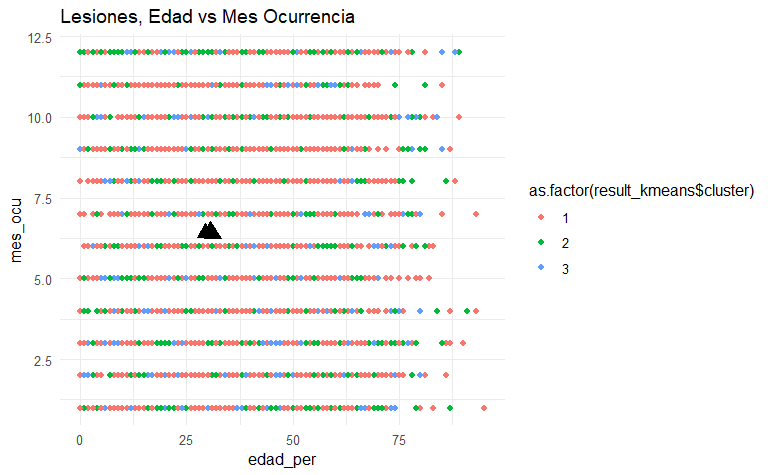

```r
victimas_cluster <- victimas%>%
  filter(edad_per <100)%>%
  filter(g_delitos == 2)%>% #Lesiones
  select(-núm_corre, -zona_ocu, -g_hora, -g_edad_60ymás, -g_edad_80ymás)



result_kmeans  <- kmeans (victimas_cluster, centers = 3)

ggplot(victimas_cluster, aes(x = edad_per , y = mes_ocu , color = as.factor(result_kmeans$cluster))) +
  geom_point() +
  geom_point(data = as.data.frame(result_kmeans$centers), aes(x = edad_per, y = mes_ocu), color = "black", size = 4, shape = 17) +
  labs(title = "Lesiones, Edad vs Mes Ocurrencia") +
  theme_minimal()
```

Podemos ver estos dos clusters. Con Grupos variados. Y aun filtrando el tipo de delito que sufrio la victima no hay grupos marcados. Los guatemaltecos y guatemaltecas sufren delitos variados.

# Clasificacion (Arboles de decision)

Para esto necesitamos las siguientes librerias

- rpart
- rpart.plot

```r
install.packages("rpart")
```

```
Error in install.packages : Updating loaded packages
```

```r
install.packages("rpart.plot")
```

```
Error in install.packages : Updating loaded packages
```

```r
library(rpart)
library(rpart.plot)
```

## Clasificacion de victimas contra su libertad

Se usan las sigueinte variables para generar un arbol de clasificacion para los delitos cometidos contra la libertad:

- Hora
- Sexo
- Edad
- Departamento

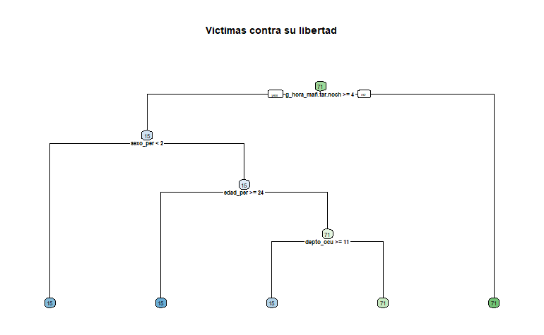

```r
victimas_arbol <- victimas %>%
  filter(g_delitos == 5)

arbol <- rpart(delito_com ~ g_hora_mañ.tar.noch+sexo_per+edad_per+depto_ocu, data=victimas_arbol, method = "class")


rpart.plot(arbol,
           type = 2,
           extra = 0,
           under = TRUE,
           fallen.leaves = TRUE,
           box.palette = "BuGn",
           main = "Victimas contra su libertad",
           cex = 0.45)
```

## Arbol para victimas contra su patriomonio

- Hora
- Sexo
- Edad
- Departamento

[figure not shown]

```r
victimas_arbol <- victimas %>%
  filter(g_delitos == 3)

arbol <- rpart(delito_com ~ g_hora_mañ.tar.noch+sexo_per+edad_per+depto_ocu, data=victimas_arbol, method = "class")


rpart.plot(arbol,
           type = 2,
           extra = 0,
           under = TRUE,
           fallen.leaves = TRUE,
           box.palette = "BuGn",
           main = "Victimas contra su libertad",
           cex = 0.45)
```